# [eb1] Analyses

Egor Ananyev

# 1 Data and function input

```r
# options(width=100)
out=F
library(plyr)
library(dplyr)
library(ggplot2)
library(lme4)
library(lmerTest)
# library(reshape2)
computer = 'acer'  # 'shocky', 'station3', 'acer' are all possible options
# if(computer == 'shocky' || computer == 'toshi'){ cloud_dir='/Users/Egor/Dropbox/' }
if(computer=='shocky' || computer=='acer'){ cloud_dir='C:/gd/' }
# if(computer == 'acer'){ cloud_dir='/Users/egora/Dropbox/' }
source(paste(cloud_dir, 'Projects/eb/eb/an/funs_an/BF_t.R', sep='/'))
source(paste(cloud_dir, 'Projects/eb/eb/an/funs_an/BF_U.R', sep='/'))
library(R.utils)
sourceDirectory(paste(cloud_dir, 'Projects/eb/eb/an/funs_an', sep='/'))
source(paste(cloud_dir, 'Prog/R/myFunctions/pvalfn.R', sep=''))
## Data input
ds = read.csv(paste(cloud_dir, 'Projects/eb/eb/an/consolidated/ds1.csv', sep='/'))
dsa = read.csv(paste(cloud_dir, 'Projects/eb/eb/an/consolidated/dsa1.csv', sep='/'))
# Reordering levels of Condition variable, such that No Blink condition is the reference:
ds$Cond = factor(ds$Cond, c('NoBlink','Artificial','Prompted'))
ds$CondFull = factor(ds$CondFull, c('No Blink','Artificial Blink','Prompted Blink'))
cue_valid_name = 'Cue Validity'
```

# 2 Cueing ~ Condition * Cue predictiveness

## 2.1 Density plots

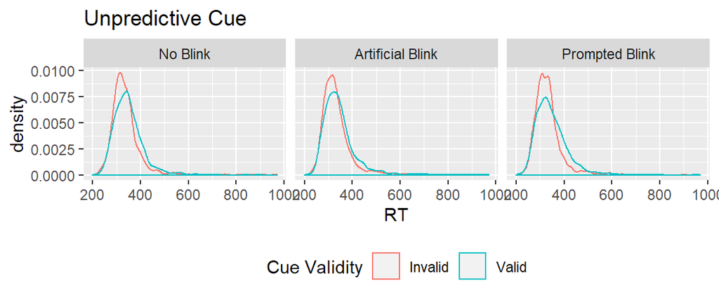

```r
plot_dens = function(cue_pred_val, plot_title){
  ggplot(data=ds[ds$cue_pred==cue_pred_val,], aes(x=RT, colour=CueValid)) +
    geom_density() + facet_grid(.~CondFull) + theme(legend.position = 'bottom') +
    ggtitle(plot_title) + guides(colour=guide_legend(title='Cue Validity'))
}
plot(plot_dens(0, 'Unpredictive Cue'))
```

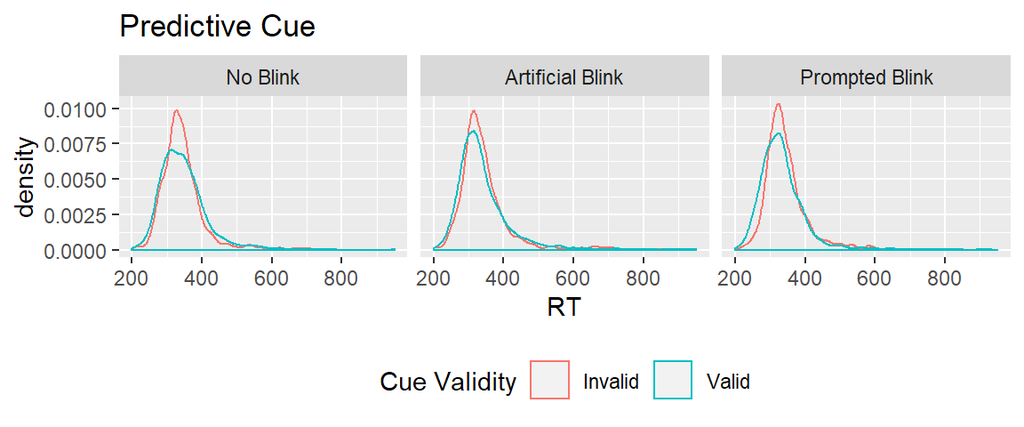

```r
plot(plot_dens(1, 'Predictive Cue'))
```

## 2.2 Cueing advantage (invalid - valid cue) box plots

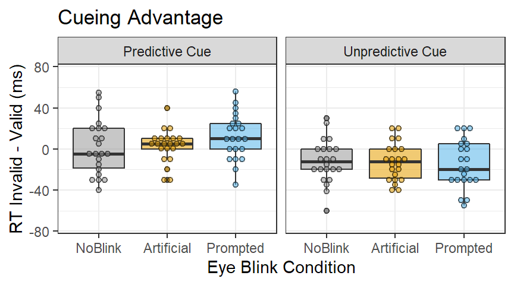

```r
ds$Cond = factor(ds$Cond, c('NoBlink','Artificial','Prompted'))
sumss_valid = ddply(ds[ds$CueValid=='Valid',], .(subj, CuePredFull, Cond), summarise,
                    RT_valid=median(RT))
sumss_invalid = ddply(ds[ds$CueValid=='Invalid',], .(subj, CuePredFull, Cond), summarise,
                      RT_invalid=median(RT))
sumss_adv = merge(sumss_valid, sumss_invalid, by=c('subj', 'CuePredFull', 'Cond'))
sumss_adv$rt_adv = sumss_adv$RT_invalid - sumss_adv$RT_valid
p = ggplot(data=sumss_adv, aes(x=Cond, y=rt_adv, fill=Cond, alpha=0.5)) +
    geom_boxplot() + facet_grid(.~CuePredFull) + xlab('Eye Blink Condition') +
    ylab('RT Invalid - Valid (ms)') + guides(alpha=F, fill=F) + ylim(-75, 75) +
    geom_dotplot(binaxis='y', stackdir='center', dotsize=2, binwidth=3) +
    theme(legend.position='none', panel.grid.minor=element_blank(),
          plot.title = element_text(hjust = 0.5)) + ggtitle('Cueing Advantage')
p = plot_themefy(p)
if(out){outpdf('eb1_rt-adv_box', w=4.5, s=T)}  # default: w=3.5, h=2.5, s(uppress)=F, j(peg)=T
suppressWarnings(plot(p))
```

## 2.3 Linear analyses

```r
# Reordering levels of Condition variable, such that No Blink condition is the reference:
ds$Cond <- factor(ds$Cond, c('Prompted','NoBlink','Artificial')) #this works for lm
# lmerfn(lmer(RT~Cond*cue_valid*cue_pred + (1|subj), data=ds))
pvalfn(lmer(RT~Cond*cue_valid*cue_pred + (1|subj), data=ds))
```

|  | estm | se | df | tVal | pVal | star |
| --- | --- | --- | --- | --- | --- | --- |
| (Intercept) | 331.600 | 4.895 | 28.636 | 67.743 | 0.000 | *** |
| CondNoBlink | 4.810 | 2.714 | 14797.145 | 1.772 | 0.076 | . |
| CondArtificial | 1.456 | 2.729 | 14797.279 | 0.533 | 0.594 |  |
| cue_valid | 16.022 | 2.741 | 14797.051 | 5.845 | 0.000 | *** |
| cue_pred | 11.511 | 3.358 | 14797.064 | 3.428 | 0.001 | *** |
| CondNoBlink:cue_valid | -3.842 | 3.836 | 14797.030 | -1.002 | 0.316 |  |
| CondArtificial:cue_valid | -2.003 | 3.858 | 14797.028 | -0.519 | 0.604 |  |
| CondNoBlink:cue_pred | -4.962 | 4.699 | 14797.074 | -1.056 | 0.291 |  |
| CondArtificial:cue_pred | -2.574 | 4.743 | 14797.147 | -0.543 | 0.587 |  |
| cue_valid:cue_pred | -24.570 | 4.191 | 14797.030 | -5.863 | 0.000 | *** |
| CondNoBlink:cue_valid:cue_pred | 14.946 | 5.856 | 14797.018 | 2.552 | 0.011 | * |
| CondArtificial:cue_valid:cue_pred | 9.327 | 5.910 | 14797.045 | 1.578 | 0.115 |  |

1. The analysis shows a clear validity effect, with a valid cue taking longer to respond to (#3), i.e., IOR.
2. If the cue is predictive, the responses are longer (#4).
3. However, if the cue is both predictive and valid, there is a facilitation instead of IOR (#9)…
4. …but not in the No Blink condition (#10).

In other words, the facilitation only occurs in the blink (artificial *and* real) conditions.

```r
# Reordering levels of Condition variable, such that No Blink condition is the reference:
# ds$Cond <- factor(ds$Cond, c('Prompted','NoBlink','Artificial')) #this works for lm
# pvalfn(lmer(RT~Cond*factor(cue_valid)*factor(cue_pred) + (1|subj), data=ds))
```

## 2.4 Bayes Factor

```r
library(BayesFactor)
bf_ss = ds
bf_ss$subj <- factor(bf_ss$subj)
bf_ss$AB = 0
bf_ss$AB[bf_ss$cond=='a'] = 1
bf_ss$PB = 0
bf_ss$PB[bf_ss$cond=='v'] = 1
bf_ss$NB = 0
bf_ss$NB[bf_ss$cond=='c'] = 1
```

```r
### Prompted vs no blink
mRes = 1/generalTestBF(RT ~ PB * cue_valid + subj,
                       data=bf_ss[bf_ss$AB==0 & bf_ss$cue_pred==1,], whichRandom='subj',
                      neverExclude='subj', whichModels='top')
print(mRes)
```

```
##                                       denominator
## numerator                              PB + cue_valid + subj
##   PB + cue_valid + PB:cue_valid + subj              3.021972
##                                       denominator
## numerator                              PB + PB:cue_valid + subj
##   PB + cue_valid + PB:cue_valid + subj                0.1587094
##                                       denominator
## numerator                              cue_valid + PB:cue_valid + subj
##   PB + cue_valid + PB:cue_valid + subj                        3170.053
```

The above analysis shows the importance of PB x validity interaction and PB condition itself in explaining the RT. The cue validity itself is not important (no simple effect).

This confirms that Prompted Blink is significantly different from No Blink condition.

```r
## Prompted vs artificial blink
mRes = 1/generalTestBF(RT ~ PB * cue_valid + subj,
                       data=bf_ss[bf_ss$NB==0 & bf_ss$cue_pred==1,], whichRandom='subj',
                       neverExclude='subj', whichModels='top')
print(mRes)
```

```
##                                       denominator
## numerator                              PB + cue_valid + subj
##   PB + cue_valid + PB:cue_valid + subj             0.2553315
##                                       denominator
## numerator                              PB + PB:cue_valid + subj
##   PB + cue_valid + PB:cue_valid + subj                0.6460855
##                                       denominator
## numerator                              cue_valid + PB:cue_valid + subj
##   PB + cue_valid + PB:cue_valid + subj                       0.8458906
```

When comparing Prompted and Artificial Blink conditions, they are statistically interchangeable (BF < 0.33).

```r
## No blink vs artificial blink
mRes = 1/generalTestBF(RT ~ AB * cue_valid + subj,
                       data=bf_ss[bf_ss$PB==0 & bf_ss$cue_pred==1,], whichRandom='subj',
                       neverExclude='subj', whichModels='top')
print(mRes)
```

```
##                                       denominator
## numerator                              AB + cue_valid + subj
##   AB + cue_valid + AB:cue_valid + subj            0.09437692
##                                       denominator
## numerator                              AB + AB:cue_valid + subj
##   AB + cue_valid + AB:cue_valid + subj               0.06658302
##                                       denominator
## numerator                              cue_valid + AB:cue_valid + subj
##   AB + cue_valid + AB:cue_valid + subj                       0.3738233
```

And so are the no-blink and AB conditions.

# 3 CTOA

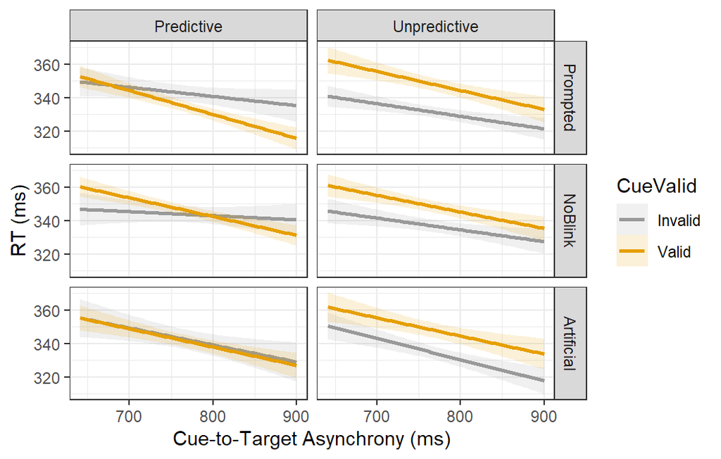

```r
## Heavy smoothing (gam)
p = ggplot(data=ds, aes(x=ctoa, y=RT, color=CueValid)) +
    geom_smooth(method='lm', alpha=0.15, aes(fill=CueValid)) +
    xlab('Cue-to-Target Asynchrony (ms)') + ylab('RT (ms)') + facet_grid(Cond~CuePred) + guides(alpha=F) +
    theme(panel.grid.minor=element_blank(), plot.title = element_text(hjust = 0.5))
p = plot_themefy(p)
if(out){outpdf('eb1_rt~ctoa_lm', w=7.5, h=3.5)}
plot(p)
```

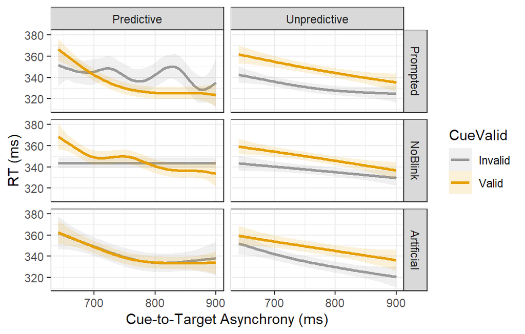

```r
## Heavy smoothing (gam)
p = ggplot(data=ds, aes(x=ctoa, y=RT, color=CueValid)) +
    geom_smooth(method='gam', alpha=0.15, aes(fill=CueValid), formula=y~s(x, bs="cs")) +
    xlab('Cue-to-Target Asynchrony (ms)') + ylab('RT (ms)') + facet_grid(Cond~CuePred) + guides(alpha=F) +
    theme(panel.grid.minor=element_blank(), plot.title = element_text(hjust = 0.5))
p = plot_themefy(p)
if(out){outpdf('eb1_rt~ctoa_gam', w=7.5, h=3.5)}
plot(p)
```

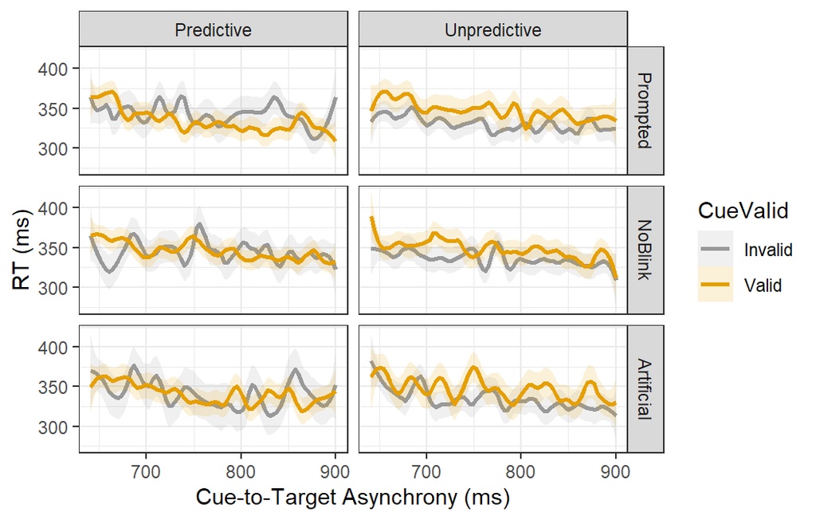

```r
## Light smoothing (loess with a small span)
p = ggplot(data=ds, aes(x=ctoa, y=RT, color=CueValid)) +
    geom_smooth(method='loess', alpha=0.15, aes(fill=CueValid), span=0.15) +
    xlab('Cue-to-Target Asynchrony (ms)') + ylab('RT (ms)') + facet_grid(Cond~CuePred) + guides(alpha=F) +
    theme(panel.grid.minor=element_blank(), plot.title = element_text(hjust = 0.5))
p = plot_themefy(p)
if(out){outpdf('eb1_rt~ctoa_loess', w=7.5, h=3.5)}
plot(p)
```

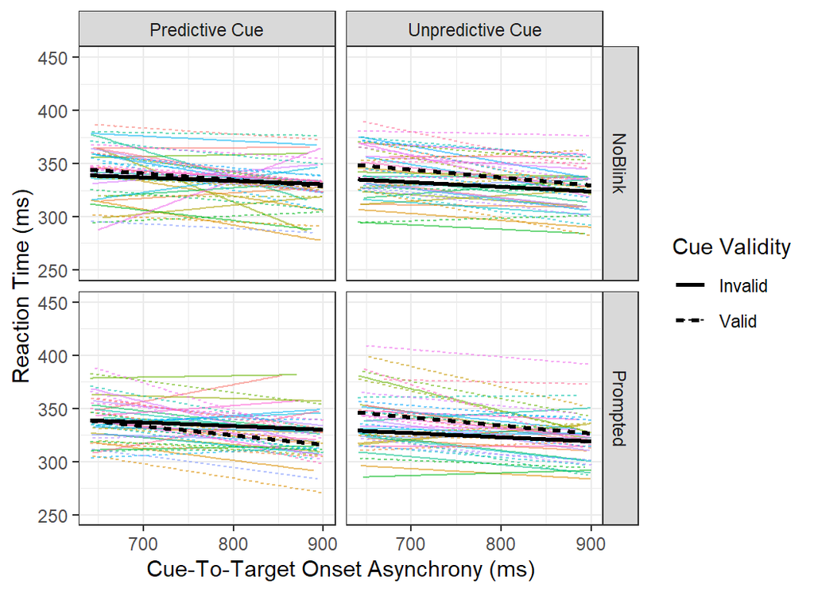

```r
## Plotting individual slopes + an average slope for CTOAs
ds$Cond <- factor(ds$Cond, c('NoBlink', 'Artificial', 'Prompted')) # this works for lm
ds_ss = ds[ds$Cond %in% c('Prompted', 'NoBlink'), ]
p = ggplot(ds_ss, aes(x=ctoa, y=RT)) + #geom_point(aes(color=factor(subj))) +
  geom_line(stat='smooth', method='lm', aes(linetype=factor(CueValid), color=factor(subj),
                                            alpha=.01), se=F) +
  geom_line(stat='smooth', method='lm', size=1, aes(linetype=factor(CueValid))) +
  facet_grid(cols=vars(CuePredFull), rows=vars(Cond)) + ylim(250,450) +
  xlab('Cue-To-Target Onset Asynchrony (ms)') + ylab('Reaction Time (ms)')+
  guides(linetype=guide_legend(title=cue_valid_name), color=F, alpha=F) + theme_bw()
if(out){outpdf('eb1_rt~ctoa-indiv_slopes', w=5.5, h=4, j=T)}
suppressWarnings(plot(p))
```

```r
# Reordering levels of Condition variable, such that No Blink condition is the reference:
ds$Cond <- factor(ds$Cond, c('Prompted','NoBlink','Artificial')) #this works for lm
pvalfn(lmer(RT~Cond*cue_valid*cue_pred*ctoa0_s + (1|subj), data=ds))
```

|  | estm | se | df | tVal | pVal | star |
| --- | --- | --- | --- | --- | --- | --- |
| (Intercept) | 343.180 | 5.867 | 58.931 | 58.496 | 0.000 | *** |
| CondNoBlink | 1.610 | 5.376 | 14785.563 | 0.299 | 0.765 |  |
| CondArtificial | 6.992 | 5.422 | 14785.477 | 1.290 | 0.197 |  |
| cue_valid | 18.324 | 5.404 | 14785.374 | 3.391 | 0.001 | *** |
| cue_pred | 4.554 | 6.379 | 14785.312 | 0.714 | 0.475 |  |
| ctoa0_s | -90.217 | 25.219 | 14785.565 | -3.577 | 0.000 | *** |
| CondNoBlink:cue_valid | -3.228 | 7.555 | 14785.396 | -0.427 | 0.669 |  |
| CondArtificial:cue_valid | -8.235 | 7.636 | 14785.429 | -1.078 | 0.281 |  |
| CondNoBlink:cue_pred | -2.634 | 9.175 | 14785.289 | -0.287 | 0.774 |  |
| CondArtificial:cue_pred | -0.683 | 9.149 | 14785.371 | -0.075 | 0.941 |  |
| cue_valid:cue_pred | -11.843 | 8.081 | 14785.369 | -1.466 | 0.143 |  |
| CondNoBlink:ctoa0_s | 26.165 | 35.885 | 14785.666 | 0.729 | 0.466 |  |
| CondArtificial:ctoa0_s | -39.891 | 36.117 | 14785.408 | -1.104 | 0.269 |  |
| cue_valid:ctoa0_s | -15.308 | 35.903 | 14785.472 | -0.426 | 0.670 |  |
| cue_pred:ctoa0_s | 52.262 | 43.833 | 14785.407 | 1.192 | 0.233 |  |
| CondNoBlink:cue_valid:cue_pred | 10.725 | 11.446 | 14785.349 | 0.937 | 0.349 |  |
| CondArtificial:cue_valid:cue_pred | 0.896 | 11.490 | 14785.558 | 0.078 | 0.938 |  |
| CondNoBlink:cue_valid:ctoa0_s | -12.122 | 50.721 | 14785.553 | -0.239 | 0.811 |  |
| CondArtificial:cue_valid:ctoa0_s | 41.494 | 50.961 | 14785.601 | 0.814 | 0.416 |  |
| CondNoBlink:cue_pred:ctoa0_s | -16.522 | 61.715 | 14785.378 | -0.268 | 0.789 |  |
| CondArtificial:cue_pred:ctoa0_s | -16.147 | 61.892 | 14785.525 | -0.261 | 0.794 |  |
| cue_valid:cue_pred:ctoa0_s | -100.419 | 54.849 | 14785.486 | -1.831 | 0.067 | . |
| CondNoBlink:cue_valid:cue_pred:ctoa0_s | 37.877 | 77.051 | 14785.439 | 0.492 | 0.623 |  |
| CondArtificial:cue_valid:cue_pred:ctoa0_s | 72.754 | 77.415 | 14785.745 | 0.940 | 0.347 |  |

1. When a target appears later (increase in CTOA), thre is a significant reduction in RT (#5).
2. There is also the IOR (#3). But no other effect is significant.

# 4 Creating blink parameter variables

```r
dsa$blink_targ_async = 1000 * (dsa$targ_time - dsa$trial_start - dsa$blank_time_end)
dsa$blink_targ_async_c = dsa$blink_targ_async - mean(dsa$blink_targ_async)
dsa$tot_blank_time = 1000 * (dsa$tot_blank_time)
dsa$tot_blank_time_c = dsa$tot_blank_time - mean(dsa$tot_blank_time)
head(dsa[,c('blank_time_beg', 'cue_time', 'trial_time_beg')])
```

| blank_time_beg | cue_time | trial_time_beg |
| --- | --- | --- |
| 0.765 | 76.67 | 76.18 |
| 0.937 | 112.46 | 112.08 |
| 0.599 | 100.94 | 100.60 |
| 0.847 | 115.06 | 114.60 |
| 0.721 | 103.50 | 103.01 |
| 1.037 | 117.64 | 117.15 |

```r
dsa$blink_latency = dsa$blank_time_beg - 1000 * (dsa$cue_time - dsa$trial_time_beg)
# Centering blink duration properly
dsa$blink_dur = dsa$tot_blank_time
blink_dur_sumss = ddply(dsa, .(Cond, subj), summarize,
                        blink_dur_ave = mean(blink_dur),
                        blink_dur_sd = sd(blink_dur))
dsa = merge(dsa, blink_dur_sumss, by=c('subj', 'Cond'))
dsa$blink_dur_z = with(dsa, (blink_dur - blink_dur_ave) / blink_dur_sd)
```

```r
(ddply(dsa[dsa$Cond=='Prompted',], .(subj), summarise,
      bdur=mean(tot_blank_time), bdur_sd=sd(tot_blank_time),
      bdur_min=min(tot_blank_time), bdur_max=max(tot_blank_time),
      bdur_sub300=sum(tot_blank_time<300), bdur_supra300=sum(tot_blank_time>300),
      total=length(tot_blank_time)))
```

| subj | bdur | bdur_sd | bdur_min | bdur_max | bdur_sub300 | bdur_supra300 | total |
| --- | --- | --- | --- | --- | --- | --- | --- |
| 1 | 166.49339 | 31.85537 | 80 | 332 | 226 | 1 | 227 |
| 3 | 178.48309 | 27.89506 | 68 | 240 | 207 | 0 | 207 |
| 4 | 120.60094 | 26.57022 | 60 | 374 | 212 | 1 | 213 |
| 5 | 157.99074 | 34.29041 | 44 | 304 | 215 | 1 | 216 |
| 6 | 134.94931 | 28.83931 | 78 | 290 | 217 | 0 | 217 |
| 7 | 156.01794 | 19.66383 | 104 | 248 | 223 | 0 | 223 |
| 8 | 130.16505 | 29.15446 | 48 | 250 | 206 | 0 | 206 |
| 9 | 99.57333 | 23.25240 | 20 | 166 | 225 | 0 | 225 |
| 10 | 150.54106 | 25.13144 | 96 | 328 | 205 | 2 | 207 |
| 12 | 175.27928 | 30.68956 | 84 | 298 | 222 | 0 | 222 |
| 14 | 142.01802 | 31.25721 | 30 | 232 | 222 | 0 | 222 |
| 15 | 191.24074 | 102.94608 | 22 | 384 | 168 | 45 | 216 |
| 16 | 200.06393 | 33.63287 | 32 | 326 | 215 | 4 | 219 |
| 17 | 132.66390 | 25.68120 | 76 | 244 | 241 | 0 | 241 |
| 18 | 163.43860 | 23.05559 | 104 | 246 | 228 | 0 | 228 |
| 19 | 92.64789 | 17.40128 | 48 | 176 | 213 | 0 | 213 |
| 20 | 141.34234 | 30.47527 | 66 | 308 | 221 | 1 | 222 |
| 21 | 162.55072 | 85.98570 | 6 | 350 | 189 | 17 | 207 |
| 22 | 178.07619 | 37.42314 | 98 | 266 | 210 | 0 | 210 |
| 23 | 102.66372 | 30.64234 | 40 | 372 | 225 | 1 | 226 |
| 24 | 117.55731 | 21.09149 | 22 | 178 | 253 | 0 | 253 |
| 25 | 155.85000 | 26.82153 | 88 | 264 | 200 | 0 | 200 |

```r
(ddply(dsa[dsa$Cond=='Prompted',], .(subj), summarise,
      blat=mean(blink_latency), blat_sd=sd(blink_latency),
      blat_min=min(blink_latency), blat_max=max(blink_latency),
      blat_sub300=sum(blink_latency<300), blat_supra300=sum(blink_latency>300),
      total=length(blink_latency)))
```

| subj | blat | blat_sd | blat_min | blat_max | blat_sub300 | blat_supra300 | total |
| --- | --- | --- | --- | --- | --- | --- | --- |
| 1 | -401.5839 | 58.59971 | -499.294 | -289.471 | 227 | 0 | 227 |
| 3 | -389.9518 | 57.73777 | -489.297 | -289.469 | 207 | 0 | 207 |
| 4 | -399.9883 | 54.66351 | -499.315 | -299.397 | 213 | 0 | 213 |
| 5 | -398.2661 | 56.00826 | -499.303 | -299.413 | 216 | 0 | 216 |
| 6 | -402.7106 | 57.19706 | -499.265 | -299.406 | 217 | 0 | 217 |
| 7 | -393.8687 | 57.81357 | -489.460 | -289.477 | 223 | 0 | 223 |
| 8 | -388.7870 | 62.09120 | -499.179 | -289.442 | 206 | 0 | 206 |
| 9 | -394.9566 | 59.09937 | -499.285 | -289.504 | 225 | 0 | 225 |
| 10 | -391.8280 | 58.78090 | -499.287 | -289.411 | 207 | 0 | 207 |
| 12 | -398.6553 | 56.97988 | -509.251 | -299.450 | 222 | 0 | 222 |
| 14 | -394.3819 | 59.50687 | -489.310 | -289.406 | 222 | 0 | 222 |
| 15 | -396.6517 | 61.78269 | -499.207 | -289.458 | 216 | 0 | 216 |
| 16 | -390.2479 | 56.21035 | -499.314 | -299.175 | 219 | 0 | 219 |
| 17 | -392.5813 | 60.65400 | -499.294 | -289.404 | 241 | 0 | 241 |
| 18 | -396.1227 | 60.20756 | -489.444 | -289.510 | 228 | 0 | 228 |
| 19 | -392.4912 | 57.56384 | -499.304 | -289.405 | 213 | 0 | 213 |
| 20 | -390.0108 | 57.43296 | -489.428 | -299.394 | 222 | 0 | 222 |
| 21 | -400.6632 | 56.77982 | -489.279 | -299.374 | 207 | 0 | 207 |
| 22 | -399.8638 | 57.53201 | -489.287 | -299.352 | 210 | 0 | 210 |
| 23 | -394.4686 | 58.43336 | -489.272 | -299.320 | 226 | 0 | 226 |
| 24 | -396.6175 | 54.94271 | -489.316 | -299.355 | 253 | 0 | 253 |
| 25 | -390.8518 | 58.89065 | -499.302 | -289.515 | 200 | 0 | 200 |

# 5 Raw blink duration

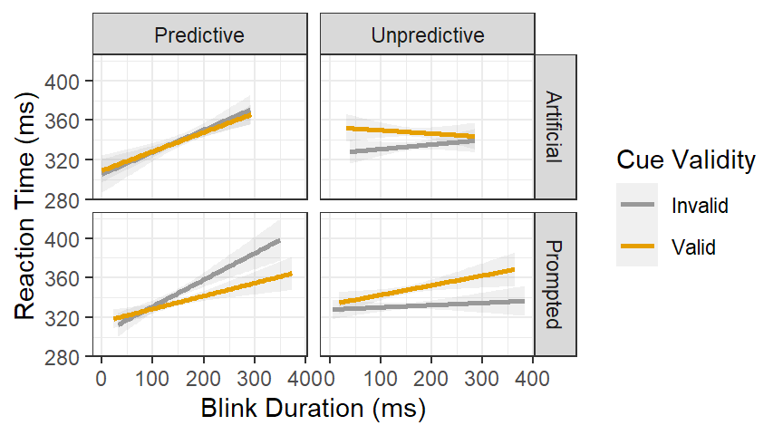

```r
p = ggplot(dsa, aes(x=blink_dur, y=RT, color=CueValid)) +
    stat_smooth(method='lm', alpha=0.15) +
    facet_grid(Cond~CuePred) + guides(color=guide_legend(title='Cue Validity')) +
    xlab('Blink Duration (ms)') + ylab('Reaction Time (ms)')
p = plot_themefy(p)
if(out){outpdf('eb1_rt~bdur_lin', w=4.5, h=2.5, s=T)}
print(p)
```

```r
dsa_temp = dsa
dsa_temp$blink_dur100 = dsa_temp$blink_dur * 10
dsa_temp$blink_dur_ms = dsa_temp$blink_dur * 1000
dsa_temp$blink_dur_c = dsa_temp$blink_dur - dsa_temp$blink_dur_ave
pvalfn(lmer(RT ~ blink_dur_c * cue_valid * cue_pred * Cond + (1|subj),  data=dsa_temp))
```

|  | estm | se | df | tVal | pVal | star |
| --- | --- | --- | --- | --- | --- | --- |
| (Intercept) | 333.236 | 5.023 | 28.080 | 66.336 | 0.000 | *** |
| blink_dur_c | 0.164 | 0.069 | 9696.579 | 2.364 | 0.018 | * |
| cue_valid | 13.929 | 2.795 | 9677.051 | 4.983 | 0.000 | *** |
| cue_pred | 8.382 | 3.461 | 9677.357 | 2.422 | 0.015 | * |
| CondPrompted | -1.649 | 2.817 | 9677.561 | -0.585 | 0.558 |  |
| blink_dur_c:cue_valid | -0.227 | 0.093 | 9677.468 | -2.441 | 0.015 | * |
| blink_dur_c:cue_pred | -0.013 | 0.102 | 9697.262 | -0.132 | 0.895 |  |
| cue_valid:cue_pred | -15.285 | 4.301 | 9677.084 | -3.554 | 0.000 | *** |
| blink_dur_c:CondPrompted | -0.178 | 0.087 | 9687.790 | -2.046 | 0.041 | * |
| cue_valid:CondPrompted | 2.152 | 3.977 | 9677.066 | 0.541 | 0.588 |  |
| cue_pred:CondPrompted | 4.011 | 4.903 | 9677.248 | 0.818 | 0.413 |  |
| blink_dur_c:cue_valid:cue_pred | 0.153 | 0.124 | 9677.377 | 1.232 | 0.218 |  |
| blink_dur_c:cue_valid:CondPrompted | 0.228 | 0.121 | 9677.503 | 1.887 | 0.059 | . |
| blink_dur_c:cue_pred:CondPrompted | 0.286 | 0.134 | 9689.946 | 2.138 | 0.033 | * |
| cue_valid:cue_pred:CondPrompted | -9.999 | 6.101 | 9677.070 | -1.639 | 0.101 |  |
| blink_dur_c:cue_valid:cue_pred:CondPrompted | -0.307 | 0.166 | 9677.496 | -1.849 | 0.064 | . |

Although from the linear plots it looks like there’s a lot more going on. But then, this effect is not meant to be conclusive.

Splitting the analyses into predictive and unpredictive portions shows blink duration effect in predictive cueing condition, but no interaction with validity, and no blink duration effect for unpredictive cues. Although those tests are underpowered and shouldn’t be used to conclude anything.

```r
### Predictive Cues
pvalfn(lmer(RT~blink_dur*cue_valid*Cond + (1|subj),  data=dsa_temp[dsa_temp$cue_pred==1,]))
```

|  | estm | se | df | tVal | pVal | star |
| --- | --- | --- | --- | --- | --- | --- |
| (Intercept) | 319.616 | 11.089 | 249.265 | 28.823 | 0.000 | *** |
| blink_dur | 0.135 | 0.055 | 4823.838 | 2.479 | 0.013 | * |
| cue_valid | 1.669 | 10.372 | 4803.821 | 0.161 | 0.872 |  |
| CondPrompted | -13.556 | 13.243 | 4814.370 | -1.024 | 0.306 |  |
| blink_dur:cue_valid | -0.018 | 0.060 | 4803.796 | -0.308 | 0.758 |  |
| blink_dur:CondPrompted | 0.122 | 0.083 | 4815.075 | 1.481 | 0.139 |  |
| cue_valid:CondPrompted | 7.175 | 14.975 | 4803.695 | 0.479 | 0.632 |  |
| blink_dur:cue_valid:CondPrompted | -0.106 | 0.093 | 4803.658 | -1.131 | 0.258 |  |

```r
### Unpredictive Cues
pvalfn(lmer(RT~blink_dur*cue_valid*Cond + (1|subj),  data=dsa_temp[dsa_temp$cue_pred==0,]))
```

|  | estm | se | df | tVal | pVal | star |
| --- | --- | --- | --- | --- | --- | --- |
| (Intercept) | 327.656 | 10.137 | 195.265 | 32.322 | 0.000 | *** |
| blink_dur | 0.039 | 0.050 | 4763.164 | 0.783 | 0.433 |  |
| cue_valid | 23.648 | 10.227 | 4853.580 | 2.312 | 0.021 | * |
| CondPrompted | 9.914 | 9.880 | 4873.157 | 1.003 | 0.316 |  |
| blink_dur:cue_valid | -0.060 | 0.061 | 4853.556 | -0.987 | 0.324 |  |
| blink_dur:CondPrompted | -0.078 | 0.060 | 4873.108 | -1.303 | 0.193 |  |
| cue_valid:CondPrompted | -21.405 | 13.185 | 4853.463 | -1.623 | 0.105 |  |
| blink_dur:cue_valid:CondPrompted | 0.152 | 0.080 | 4853.535 | 1.891 | 0.059 | . |

# 6 Normalized blink duration

## 6.1 Continuous blink duration

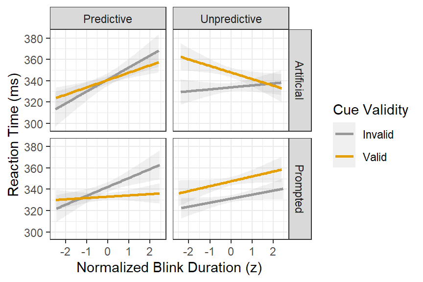

```r
p = ggplot(dsa, aes(x=blink_dur_z, y=RT, color=CueValid)) +
    stat_smooth(method='lm', alpha=0.15) + xlab('Normalized Blink Duration (z)') +
    xlim(-2.5, 2.5) + facet_grid(Cond~CuePred) + ylab('Reaction Time (ms)') +
    guides(color=guide_legend(title='Cue Validity'))
p = plot_themefy(p)
if(out){outpdf('eb1_rt~bdur-z_lin', w=4.5, h=3.5, s=T)}
suppressWarnings(plot(p))
```

```r
p = ggplot(dsa, aes(x=blink_dur_z, y=RT, color=CueValid)) +
    xlab('Normalized Blink Duration (z)') +
    stat_smooth(method='gam', formula=y~s(x, bs='cs'), alpha=0.15) +
    xlim(-2.5, 2.5) + facet_grid(Cond~CuePred) + ylab('Reaction Time (ms)')
    guides(color=guide_legend(title='Cue Validity'))
```

[output not shown]

[output cut: 14 more lines]

[output not shown]

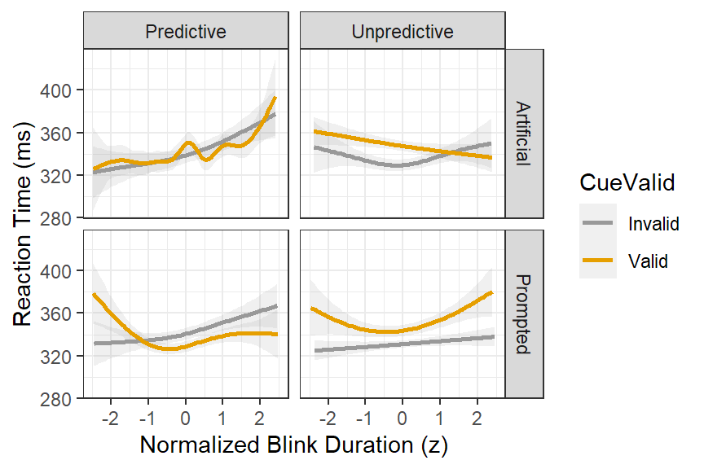

```r
p = plot_themefy(p)
suppressWarnings(plot(p))
```

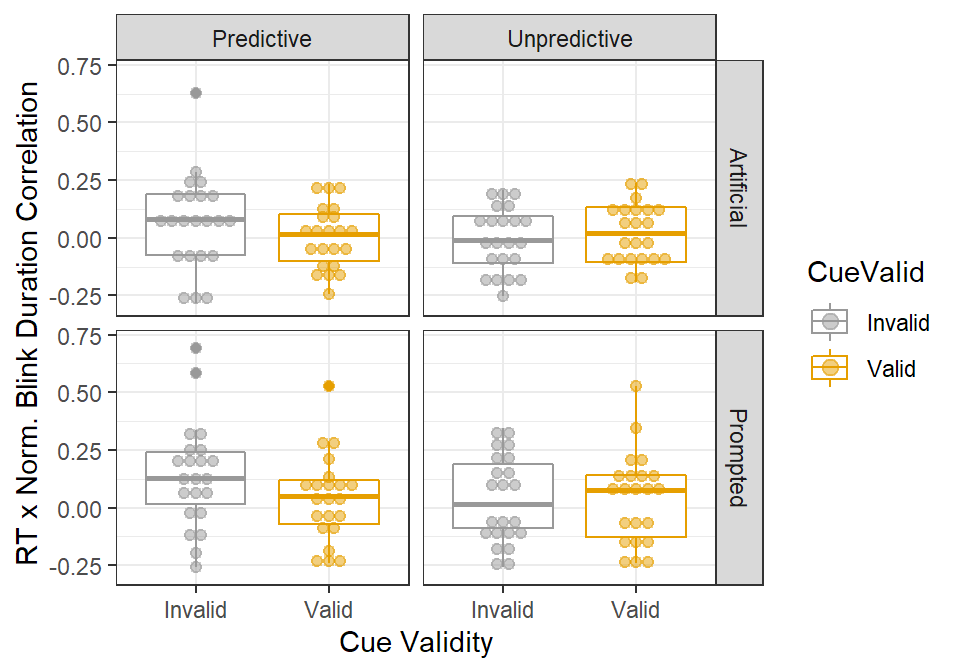

```r
cor_blink_dur_z = ddply(dsa, .(subj, CueValid, Cond, CuePred), summarise,
                        corcoeff = cor(RT, blink_dur))
p = ggplot(cor_blink_dur_z, aes(x=CueValid, y=corcoeff, color=CueValid)) +
    geom_boxplot() + facet_grid(Cond~CuePred) + xlab('Cue Validity') +
    geom_dotplot(binaxis='y', stackdir='center', dotsize=1, binwidth=.05, alpha=0.5,
                 aes(fill=CueValid)) +
    ylab('RT x Norm. Blink Duration Correlation')
p = plot_themefy(p)
if(out){outpdf('eb1_rt~bdur-z_cor', w=5.0, h=3.5, s=T)}
print(p)
```

```r
pvalfn(lmer(RT~blink_dur_z*cue_valid*cue_pred*Cond + (1|subj),  data=dsa))
```

|  | estm | se | df | tVal | pVal | star |
| --- | --- | --- | --- | --- | --- | --- |
| (Intercept) | 333.139 | 5.039 | 28.001 | 66.112 | 0.000 | *** |
| blink_dur_z | 5.811 | 2.243 | 9692.088 | 2.590 | 0.010 | * |
| cue_valid | 14.060 | 2.793 | 9677.033 | 5.035 | 0.000 | *** |
| cue_pred | 8.429 | 3.459 | 9677.364 | 2.437 | 0.015 | * |
| CondPrompted | -1.648 | 2.811 | 9677.429 | -0.586 | 0.558 |  |
| blink_dur_z:cue_valid | -7.351 | 3.027 | 9677.709 | -2.429 | 0.015 | * |
| blink_dur_z:cue_pred | 0.038 | 3.600 | 9694.244 | 0.010 | 0.992 |  |
| cue_valid:cue_pred | -15.308 | 4.298 | 9677.063 | -3.562 | 0.000 | *** |
| blink_dur_z:CondPrompted | -4.527 | 3.067 | 9688.454 | -1.476 | 0.140 |  |
| cue_valid:CondPrompted | 2.140 | 3.970 | 9677.047 | 0.539 | 0.590 |  |
| cue_pred:CondPrompted | 3.696 | 4.893 | 9677.241 | 0.755 | 0.450 |  |
| blink_dur_z:cue_valid:cue_pred | 5.204 | 4.353 | 9677.764 | 1.195 | 0.232 |  |
| blink_dur_z:cue_valid:CondPrompted | 8.579 | 4.243 | 9677.543 | 2.022 | 0.043 | * |
| blink_dur_z:cue_pred:CondPrompted | 9.949 | 4.969 | 9690.345 | 2.002 | 0.045 | * |
| cue_valid:cue_pred:CondPrompted | -9.927 | 6.090 | 9677.054 | -1.630 | 0.103 |  |
| blink_dur_z:cue_valid:cue_pred:CondPrompted | -12.151 | 6.121 | 9677.586 | -1.985 | 0.047 | * |

…I threw several attempts at trying to interpret this table, to no avail. I think it’s best to simplify this analysis with the mean split.

Effects #2, 3, and 7 are consistent with other analyses. With regards to the inter-trial variation in blink durations:

1. Trials with longer blinks are generally associated with a slowed response to the target following an invalid cue (#1),
2. When the cues were uninformative,
   1. trials with longer artificial blinks did not show the IOR (#5);
   2. this was not the case for real blinks (#12).
3. With the informative cues:
   1. Trials with longer real blinks show an increased reaction time to invalidly cued targets (#13),
   2. but faster reaction to the validly cued targets (#15).

With informative cues, trials with longer blinks were associated with attentional facilitation , especially with real blinks.

## 6.2 Mean duration split

```r
dsa$blink_dur_split = 'Short Blink'
dsa$blink_dur_split[dsa$blink_dur_z > 0] = 'Long Blink'
dsa$blink_dur_split = factor(dsa$blink_dur_split, c('Short Blink', 'Long Blink'))
```

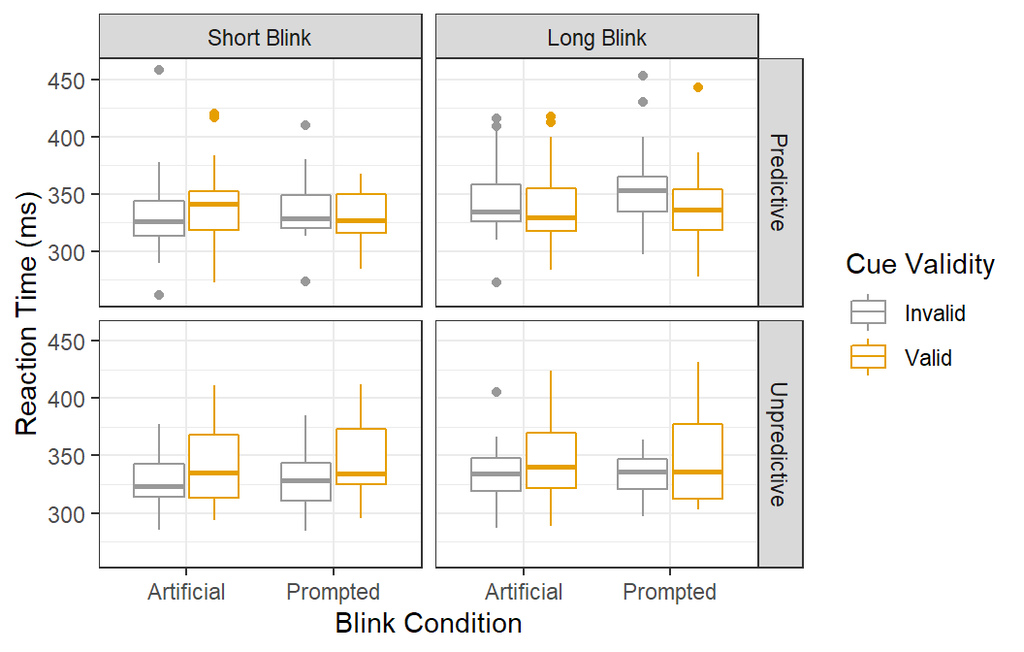

```r
sumss = ddply(dsa, .(subj, CuePred, Cond, CueValid, blink_dur_split), summarise, RT=mean(RT))
p = ggplot(sumss, aes(x=Cond, y=RT, color=CueValid)) + geom_boxplot() +
    facet_grid(CuePred~blink_dur_split) + guides(color=guide_legend(title='Cue Validity')) +
    # geom_dotplot(binaxis='y', stackdir='center', dotsize=2, binwidth=3) +
    xlab('Blink Condition') + ylab('Reaction Time (ms)')
p = plot_themefy(p)
if(out){outpdf('eb1_rt~bdur-z-split_box', w=5.5, h=3.5)}
print(p)
```

```r
pvalfn(lmer(RT~blink_dur_split*cue_valid*cue_pred*Cond + (1|subj),  data=dsa))
```

|  | estm | se | df | tVal | pVal | star |
| --- | --- | --- | --- | --- | --- | --- |
| (Intercept) | 327.591 | 5.466 | 38.709 | 59.928 | 0.000 | *** |
| blink_dur_splitLong Blink | 10.720 | 4.048 | 9693.257 | 2.648 | 0.008 | ** |
| cue_valid | 20.531 | 3.985 | 9677.255 | 5.152 | 0.000 | *** |
| cue_pred | 7.005 | 5.129 | 9688.474 | 1.366 | 0.172 |  |
| CondPrompted | 2.123 | 4.033 | 9683.897 | 0.527 | 0.599 |  |
| blink_dur_splitLong Blink:cue_valid | -12.506 | 5.592 | 9677.477 | -2.236 | 0.025 | * |
| blink_dur_splitLong Blink:cue_pred | 2.871 | 7.098 | 9694.380 | 0.404 | 0.686 |  |
| cue_valid:cue_pred | -18.104 | 6.223 | 9677.502 | -2.909 | 0.004 | ** |
| blink_dur_splitLong Blink:CondPrompted | -6.970 | 5.699 | 9688.059 | -1.223 | 0.221 |  |
| cue_valid:CondPrompted | -4.742 | 5.582 | 9677.286 | -0.850 | 0.396 |  |
| cue_pred:CondPrompted | -2.328 | 6.951 | 9684.580 | -0.335 | 0.738 |  |
| blink_dur_splitLong Blink:cue_valid:cue_pred | 5.306 | 8.613 | 9677.736 | 0.616 | 0.538 |  |
| blink_dur_splitLong Blink:cue_valid:CondPrompted | 13.401 | 7.952 | 9677.554 | 1.685 | 0.092 | . |
| blink_dur_splitLong Blink:cue_pred:CondPrompted | 13.272 | 9.975 | 9689.544 | 1.331 | 0.183 |  |
| cue_valid:cue_pred:CondPrompted | -2.131 | 8.549 | 9677.621 | -0.249 | 0.803 |  |
| blink_dur_splitLong Blink:cue_valid:cue_pred:CondPrompted | -16.087 | 12.228 | 9677.941 | -1.316 | 0.188 |  |

Model baseline: AB, Unpredictive & Invalid Cue, Short Blink

Given the baseline, we observe the IOR for Unpredictive Cues (#2) and facilitation for Predictive Cues (#7).

- Longer blinks are associated with ~11 ms slowdown in response.
- Longer blinks are associated with a reduced IOR in the Unpredictive Cue condition.

The latter is not at all apparent looking at the plots: There should be less of a difference in RTs between valid and invalid cues in lower right corner when compared to the lower left corner.

Regardless, none of the effects seem to have anything to do with the blink condition.

# 7 Individual differences in blink duration

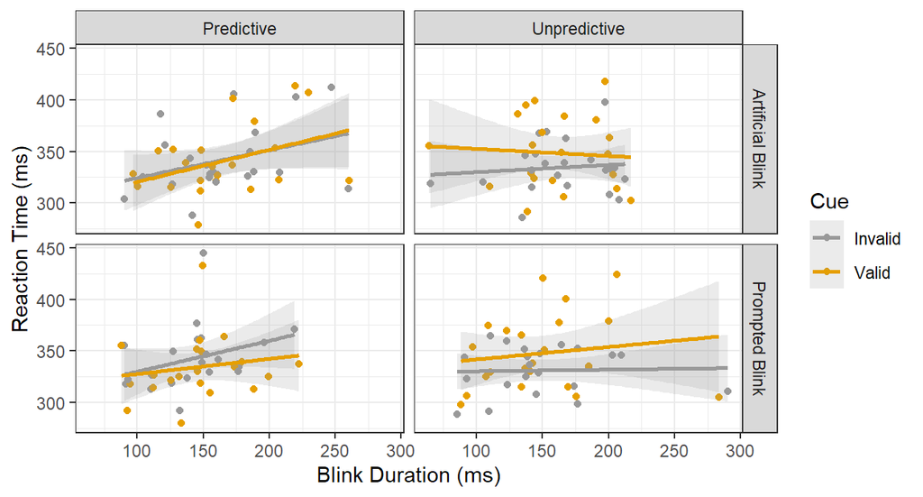

```r
bdur_rt_cond_ctoa = ddply(dsa, .(subj, CueValid, CondFull, CuePred), summarise,
                RT=mean(RT), bdur=mean(blink_dur), bdur_min=min(blink_dur),
                bdur_max=max(blink_dur), bdur_sd=sd(blink_dur),
                bdur_supra300=length(blink_dur>300))
p = ggplot(bdur_rt_cond_ctoa, aes(x=bdur, y=RT)) + geom_point(aes(color=factor(CueValid))) +
    stat_smooth(method='lm', aes(color=factor(CueValid)), alpha=.2) +
    facet_grid(CondFull~CuePred) +
    xlab('Blink Duration (ms)') + ylab('Reaction Time (ms)')+
    guides(colour=guide_legend(title='Cue')) + theme_bw()
p = plot_themefy(p)
if(out){outpdf('eb1_rt~bdur-indiv_lin', w=5.5)}
plot(p)
```

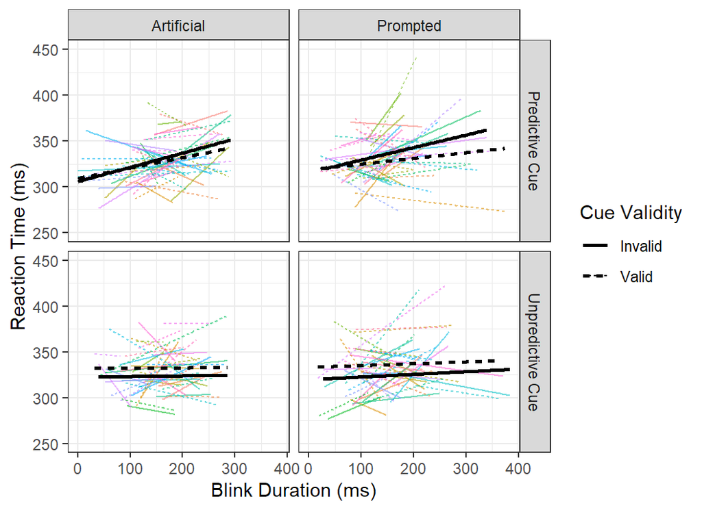

```r
## Plotting individual slopes + an average slope
p = ggplot(dsa, aes(x=tot_blank_time, y=RT)) + #geom_point(aes(color=factor(subj))) +
  geom_line(stat='smooth', method='lm', aes(linetype=factor(CueValid), color=factor(subj),
                                            alpha=.01), se=F) +
  geom_line(stat='smooth', method='lm', size=1, aes(linetype=factor(CueValid))) +
  facet_grid(CuePredFull~Cond) + ylim(250,450) +
  xlab('Blink Duration (ms)') + ylab('Reaction Time (ms)')+
  guides(linetype=guide_legend(title=cue_valid_name), color=F, alpha=F) + theme_bw()
if(out){outpdf('eb1_rt~bdur-indiv_slopes', w=5.5, h=4, s=T)}
suppressWarnings(plot(p))
```

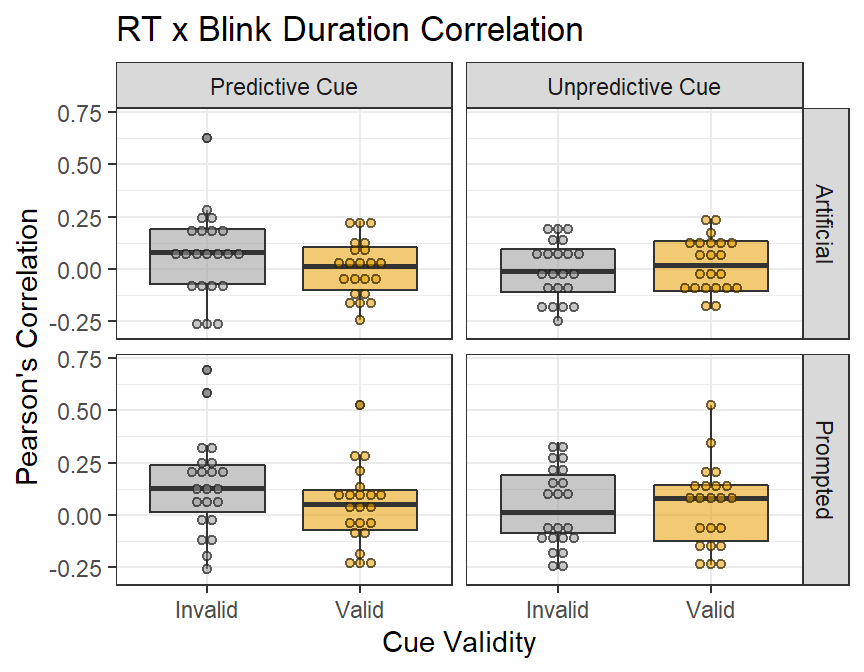

```r
bdur_rt_corr = ddply(dsa, .(Cond, subj, CuePredFull, CueValid), summarise,
                corr = cor(tot_blank_time, RT))
p = ggplot(data=bdur_rt_corr, aes(x=CueValid, y=corr, fill=CueValid, alpha=0.5)) +
    geom_boxplot() + facet_grid(Cond~CuePredFull) + xlab('Cue Validity') +
    ylab('Pearson\'s Correlation') + guides(alpha=F, fill=F) +
    geom_dotplot(binaxis='y', stackdir='center', dotsize=1, binwidth=.05) +
    theme(legend.position='none', panel.grid.minor=element_blank(),
          plot.title = element_text(hjust = 0.5)) + ggtitle('RT x Blink Duration Correlation')
p = plot_themefy(p)
if(out){outpdf('eb1_rt~bdur-indiv_cor', w=4.5, h=3.5)}
plot(p)
```

```r
dsa$blink_dur_ave_c = with(dsa, blink_dur_ave - mean(blink_dur_ave))  # centering the continuous variable
pvalfn(lmer(RT~blink_dur_ave_c*cue_valid*cue_pred*Cond + (1|subj), data=dsa))
```

|  | estm | se | df | tVal | pVal | star |
| --- | --- | --- | --- | --- | --- | --- |
| (Intercept) | 333.447 | 4.983 | 29.043 | 66.912 | 0.000 | *** |
| blink_dur_ave_c | -0.027 | 0.067 | 8679.257 | -0.407 | 0.684 |  |
| cue_valid | 13.513 | 2.879 | 9677.120 | 4.693 | 0.000 | *** |
| cue_pred | 6.889 | 3.552 | 9677.410 | 1.940 | 0.052 | . |
| CondPrompted | -1.902 | 2.964 | 9696.860 | -0.642 | 0.521 |  |
| blink_dur_ave_c:cue_valid | 0.064 | 0.081 | 9677.088 | 0.782 | 0.434 |  |
| blink_dur_ave_c:cue_pred | 0.230 | 0.102 | 9677.294 | 2.250 | 0.024 | * |
| cue_valid:cue_pred | -15.388 | 4.414 | 9677.171 | -3.486 | 0.000 | *** |
| blink_dur_ave_c:CondPrompted | 0.026 | 0.095 | 9693.342 | 0.270 | 0.787 |  |
| cue_valid:CondPrompted | 4.779 | 4.108 | 9677.182 | 1.163 | 0.245 |  |
| cue_pred:CondPrompted | 4.807 | 5.049 | 9677.318 | 0.952 | 0.341 |  |
| blink_dur_ave_c:cue_valid:cue_pred | -0.018 | 0.127 | 9677.130 | -0.138 | 0.890 |  |
| blink_dur_ave_c:cue_valid:CondPrompted | 0.215 | 0.128 | 9677.185 | 1.683 | 0.092 | . |
| blink_dur_ave_c:cue_pred:CondPrompted | -0.200 | 0.157 | 9677.298 | -1.269 | 0.205 |  |
| cue_valid:cue_pred:CondPrompted | -11.369 | 6.286 | 9677.187 | -1.809 | 0.071 | . |
| blink_dur_ave_c:cue_valid:cue_pred:CondPrompted | -0.263 | 0.196 | 9677.216 | -1.341 | 0.180 |  |

There’s the IOR (#2) and its reversal in predictive cue condition (#7), as well as the general slow-down in the predictive cue condition (#3). Consistent with the previous analyses, there is no difference between artificial and real blinks.

Additionally, people with longer average blinks have their RT slowed in the predictive cue condition (#6).

# 8 Blink latency

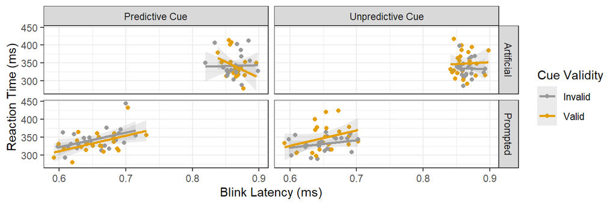

```r
blat_rt = ddply(dsa, .(subj, CuePredFull, CueValid, Cond), summarise,
                blat = mean(blank_time_beg), RT = mean(RT))
p = ggplot(blat_rt, aes(x=blat, y=RT)) + geom_point(aes(color=CueValid)) +
  stat_smooth(method='lm', aes(color=CueValid), alpha=.2) +
  facet_grid(Cond~CuePredFull) + xlab('Blink Latency (ms)') + ylab('Reaction Time (ms)') +
  guides(colour=guide_legend(title=cue_valid_name)) + theme_bw() +
  theme(legend.position=c(1.1, .75), legend.title=element_blank(),
        legend.box.background = element_rect(colour = "black"),
        legend.spacing.y = unit(0, "mm"))
p = plot_themefy(p)
if(out){outpdf('eb1_rt~blat-indiv', w=7.5, h=4.5, s=T)}
plot(p)
```

# 9 Blink-target asynchrony

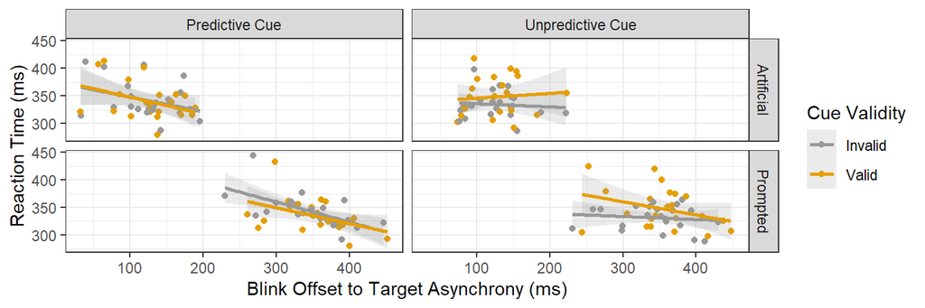

```r
bota_rt = ddply(dsa, .(subj, CuePredFull, CueValid, Cond), summarise,
                bota = mean(blink_targ_async), RT = mean(RT))
p = ggplot(bota_rt, aes(x=bota, y=RT)) + geom_point(aes(color=CueValid)) +
  stat_smooth(method='lm', aes(color=CueValid), alpha=.2) +
  facet_grid(Cond~CuePredFull) + xlab('Blink Offset to Target Asynchrony (ms)') +
  ylab('Reaction Time (ms)') + guides(colour=guide_legend(title=cue_valid_name)) + theme_bw() +
  theme(legend.position='none')
p = plot_themefy(p)
if(out){outpdf('eb1_rt~bota-indiv', w=7.5, h=4.5)}
plot(p)
```

# 10 Session, condition, and block order

```r
## "session order" variable:
sumss_block = ddply(ds, .(subj, block_date), summarise, sess_order = 0)
sumss_block = sumss_block %>% group_by(subj) %>% mutate(sess_order=order(block_date))
head(sumss_block)
```

| subj | block_date | sess_order |
| --- | --- | --- |
| 1 | 2019-06-24 | 1 |
| 1 | 2019-06-27 | 2 |
| 3 | 2019-06-25 | 1 |
| 3 | 2019-07-04 | 2 |
| 4 | 2019-06-28 | 1 |
| 4 | 2019-07-04 | 2 |

```r
dsa_order = merge(dsa, sumss_block, by=c('subj', 'block_date'))
ds_order = merge(ds, sumss_block, by=c('subj', 'block_date'))
## "condition order" variable
sumss_cond = ddply(ds[ds$block_order==1,], .(subj, block_date, Cond, block_time), summarise,
                   cond_order = 0)
sumss_cond = sumss_cond %>% group_by(subj, block_date) %>% mutate(cond_order=order(order(block_time)))
# ... I've no idea why I need to double-wrap order(), but I have to to make it work right.
head(sumss_cond, 12)
```

| subj | block_date | Cond | block_time | cond_order |
| --- | --- | --- | --- | --- |
| 1 | 2019-06-24 | Prompted | 1619 | 1 |
| 1 | 2019-06-24 | NoBlink | 1635 | 2 |
| 1 | 2019-06-24 | Artificial | 1651 | 3 |
| 1 | 2019-06-27 | Prompted | 1301 | 1 |
| 1 | 2019-06-27 | NoBlink | 1310 | 2 |
| 1 | 2019-06-27 | Artificial | 1321 | 3 |
| 3 | 2019-06-25 | Prompted | 1420 | 3 |
| 3 | 2019-06-25 | NoBlink | 1407 | 2 |
| 3 | 2019-06-25 | Artificial | 1352 | 1 |
| 3 | 2019-07-04 | Prompted | 1420 | 3 |
| 3 | 2019-07-04 | NoBlink | 1410 | 2 |
| 3 | 2019-07-04 | Artificial | 1359 | 1 |

```r
# since we're not merging by block time, dropping it first:
sumss_cond = subset(sumss_cond, select=-c(block_time))
dsa_order = merge(dsa_order, sumss_cond, by=c('subj', 'block_date', 'Cond'))
ds_order = merge(ds_order, sumss_cond, by=c('subj', 'block_date', 'Cond'))
## "block order" variable
ds_order$BlockOrder = '5th Block'
ds_order$BlockOrder[ds_order$block_order==1] = '1st Block'
ds_order$BlockOrder[ds_order$block_order==2] = '2nd Block'
ds_order$BlockOrder[ds_order$block_order==3] = '3rd Block'
ds_order$BlockOrder[ds_order$block_order==4] = '4th Block'
dsa_order$BlockOrder = '5th Block'
dsa_order$BlockOrder[dsa_order$block_order==1] = '1st Block'
dsa_order$BlockOrder[dsa_order$block_order==2] = '2nd Block'
dsa_order$BlockOrder[dsa_order$block_order==3] = '3rd Block'
dsa_order$BlockOrder[dsa_order$block_order==4] = '4th Block'
head(ds_order[,c('block_date', 'block_time', 'block_order', 'sess_order', 'cond_order')])
```

| block_date | block_time | block_order | sess_order | cond_order |
| --- | --- | --- | --- | --- |
| 2019-06-24 | 1651 | 1 | 1 | 3 |
| 2019-06-24 | 1651 | 1 | 1 | 3 |
| 2019-06-24 | 1651 | 1 | 1 | 3 |
| 2019-06-24 | 1651 | 1 | 1 | 3 |
| 2019-06-24 | 1651 | 1 | 1 | 3 |
| 2019-06-24 | 1651 | 1 | 1 | 3 |

## 10.1 Nuisance models

### 10.1.1 Without blink parameters

Comparing against the nuisance-free model:

```r
ds_order$Cond <- factor(ds_order$Cond, c('Prompted','NoBlink','Artificial')) #this works for lm
pvalfn(lmer(RT~Cond*cue_valid*cue_pred + (1|subj), data=ds_order))
```

|  | estm | se | df | tVal | pVal | star |
| --- | --- | --- | --- | --- | --- | --- |
| (Intercept) | 331.600 | 4.895 | 28.636 | 67.743 | 0.000 | *** |
| CondNoBlink | 4.810 | 2.714 | 14797.145 | 1.772 | 0.076 | . |
| CondArtificial | 1.456 | 2.729 | 14797.279 | 0.533 | 0.594 |  |
| cue_valid | 16.022 | 2.741 | 14797.051 | 5.845 | 0.000 | *** |
| cue_pred | 11.511 | 3.358 | 14797.064 | 3.428 | 0.001 | *** |
| CondNoBlink:cue_valid | -3.842 | 3.836 | 14797.030 | -1.002 | 0.316 |  |
| CondArtificial:cue_valid | -2.003 | 3.858 | 14797.028 | -0.519 | 0.604 |  |
| CondNoBlink:cue_pred | -4.962 | 4.699 | 14797.074 | -1.056 | 0.291 |  |
| CondArtificial:cue_pred | -2.574 | 4.743 | 14797.147 | -0.543 | 0.587 |  |
| cue_valid:cue_pred | -24.570 | 4.191 | 14797.030 | -5.863 | 0.000 | *** |
| CondNoBlink:cue_valid:cue_pred | 14.946 | 5.856 | 14797.018 | 2.552 | 0.011 | * |
| CondArtificial:cue_valid:cue_pred | 9.327 | 5.910 | 14797.045 | 1.578 | 0.115 |  |

Nuisance model:

```r
ds_order$sess_order_0 = ds_order$sess_order - 1  # zero is first session
ds_order$cond_order_c = ds_order$cond_order - 1  # centered on second block
ds_order$block_order_c = ds_order$block_order - 1  # centered on second condition
pvalfn(lmer(RT ~ Cond * cue_valid * cue_pred + sess_order_0 + cond_order_c + block_order_c +
              (1|subj), data=ds_order))
```

|  | estm | se | df | tVal | pVal | star |
| --- | --- | --- | --- | --- | --- | --- |
| (Intercept) | 351.708 | 5.027 | 31.089 | 69.969 | 0.000 | *** |
| CondNoBlink | 4.558 | 2.663 | 14794.136 | 1.712 | 0.087 | . |
| CondArtificial | 1.459 | 2.678 | 14794.264 | 0.545 | 0.586 |  |
| cue_valid | 15.897 | 2.689 | 14794.049 | 5.911 | 0.000 | *** |
| cue_pred | 13.467 | 3.296 | 14794.062 | 4.086 | 0.000 | *** |
| sess_order_0 | -23.055 | 1.090 | 14794.226 | -21.145 | 0.000 | *** |
| cond_order_c | -2.113 | 0.668 | 14794.389 | -3.164 | 0.002 | ** |
| block_order_c | -6.974 | 0.647 | 14795.780 | -10.784 | 0.000 | *** |
| CondNoBlink:cue_valid | -3.737 | 3.763 | 14794.029 | -0.993 | 0.321 |  |
| CondArtificial:cue_valid | -1.911 | 3.784 | 14794.027 | -0.505 | 0.614 |  |
| CondNoBlink:cue_pred | -4.824 | 4.610 | 14794.070 | -1.046 | 0.295 |  |
| CondArtificial:cue_pred | -3.429 | 4.654 | 14794.140 | -0.737 | 0.461 |  |
| cue_valid:cue_pred | -24.516 | 4.112 | 14794.029 | -5.963 | 0.000 | *** |
| CondNoBlink:cue_valid:cue_pred | 14.948 | 5.745 | 14794.018 | 2.602 | 0.009 | ** |
| CondArtificial:cue_valid:cue_pred | 9.583 | 5.798 | 14794.044 | 1.653 | 0.098 | . |

### 10.1.2 With blink parameters

Nuisance-free model:

```r
dsa_temp = dsa
dsa_temp$blink_dur_c = dsa_temp$blink_dur - dsa_temp$blink_dur_ave
pvalfn(lmer(RT ~ blink_dur_c * cue_valid * cue_pred * Cond + (1|subj),  data=dsa_temp))
```

|  | estm | se | df | tVal | pVal | star |
| --- | --- | --- | --- | --- | --- | --- |
| (Intercept) | 333.236 | 5.023 | 28.080 | 66.336 | 0.000 | *** |
| blink_dur_c | 0.164 | 0.069 | 9696.579 | 2.364 | 0.018 | * |
| cue_valid | 13.929 | 2.795 | 9677.051 | 4.983 | 0.000 | *** |
| cue_pred | 8.382 | 3.461 | 9677.357 | 2.422 | 0.015 | * |
| CondPrompted | -1.649 | 2.817 | 9677.561 | -0.585 | 0.558 |  |
| blink_dur_c:cue_valid | -0.227 | 0.093 | 9677.468 | -2.441 | 0.015 | * |
| blink_dur_c:cue_pred | -0.013 | 0.102 | 9697.262 | -0.132 | 0.895 |  |
| cue_valid:cue_pred | -15.285 | 4.301 | 9677.084 | -3.554 | 0.000 | *** |
| blink_dur_c:CondPrompted | -0.178 | 0.087 | 9687.790 | -2.046 | 0.041 | * |
| cue_valid:CondPrompted | 2.152 | 3.977 | 9677.066 | 0.541 | 0.588 |  |
| cue_pred:CondPrompted | 4.011 | 4.903 | 9677.248 | 0.818 | 0.413 |  |
| blink_dur_c:cue_valid:cue_pred | 0.153 | 0.124 | 9677.377 | 1.232 | 0.218 |  |
| blink_dur_c:cue_valid:CondPrompted | 0.228 | 0.121 | 9677.503 | 1.887 | 0.059 | . |
| blink_dur_c:cue_pred:CondPrompted | 0.286 | 0.134 | 9689.946 | 2.138 | 0.033 | * |
| cue_valid:cue_pred:CondPrompted | -9.999 | 6.101 | 9677.070 | -1.639 | 0.101 |  |
| blink_dur_c:cue_valid:cue_pred:CondPrompted | -0.307 | 0.166 | 9677.496 | -1.849 | 0.064 | . |

Nuisance model:

```r
dsa_order$sess_order_0 = dsa_order$sess_order - 1  # zero is first session
dsa_order$cond_order_c = dsa_order$cond_order - 1  # centered on second block
dsa_order$block_order_c = dsa_order$block_order - 1  # centered on second condition
dsa_order$blink_dur_c = dsa_order$blink_dur - dsa_order$blink_dur_ave
pvalfn(lmer(RT ~ blink_dur_c * Cond * cue_valid * cue_pred + sess_order_0 + cond_order_c + block_order_c +
              (1|subj), data=dsa_order))
```

|  | estm | se | df | tVal | pVal | star |
| --- | --- | --- | --- | --- | --- | --- |
| (Intercept) | 356.704 | 5.205 | 32.471 | 68.532 | 0.000 | *** |
| blink_dur_c | 0.181 | 0.068 | 9693.099 | 2.657 | 0.008 | ** |
| CondPrompted | -1.943 | 2.751 | 9675.162 | -0.706 | 0.480 |  |
| cue_valid | 13.911 | 2.727 | 9674.066 | 5.101 | 0.000 | *** |
| cue_pred | 9.601 | 3.378 | 9674.335 | 2.843 | 0.004 | ** |
| sess_order_0 | -26.362 | 1.388 | 9674.432 | -18.987 | 0.000 | *** |
| cond_order_c | -1.784 | 1.023 | 9486.447 | -1.744 | 0.081 | . |
| block_order_c | -9.007 | 0.814 | 9677.578 | -11.065 | 0.000 | *** |
| blink_dur_c:CondPrompted | -0.131 | 0.086 | 9689.360 | -1.525 | 0.127 |  |
| blink_dur_c:cue_valid | -0.217 | 0.091 | 9674.483 | -2.396 | 0.017 | * |
| CondPrompted:cue_valid | 2.172 | 3.880 | 9674.083 | 0.560 | 0.576 |  |
| blink_dur_c:cue_pred | -0.030 | 0.100 | 9693.855 | -0.304 | 0.761 |  |
| CondPrompted:cue_pred | 5.476 | 4.784 | 9674.236 | 1.145 | 0.252 |  |
| cue_valid:cue_pred | -14.900 | 4.196 | 9674.097 | -3.551 | 0.000 | *** |
| blink_dur_c:CondPrompted:cue_valid | 0.211 | 0.118 | 9674.498 | 1.794 | 0.073 | . |
| blink_dur_c:CondPrompted:cue_pred | 0.304 | 0.132 | 9691.586 | 2.299 | 0.022 | * |
| blink_dur_c:cue_valid:cue_pred | 0.141 | 0.121 | 9674.391 | 1.167 | 0.243 |  |
| CondPrompted:cue_valid:cue_pred | -10.559 | 5.952 | 9674.083 | -1.774 | 0.076 | . |
| blink_dur_c:CondPrompted:cue_valid:cue_pred | -0.281 | 0.162 | 9674.493 | -1.731 | 0.084 | . |

The interaction between blink duration and prompted condition is no longer significant, but everything else holds up.

The ‘basic effects’: cue validity (#3) and predictiveness (#4) as well as their interaction (#13).

Just out of curiousity, looking into the effects of nuisance parameters on blink duration:

```r
pvalfn(lmer(blink_dur ~ Cond * sess_order_0 * cond_order_c * block_order_c + (1|subj), data=dsa_order))
```

|  | estm | se | df | tVal | pVal | star |
| --- | --- | --- | --- | --- | --- | --- |
| (Intercept) | 148.197 | 6.063 | 27.106 | 24.444 | 0.000 | *** |
| CondPrompted | -0.783 | 3.324 | 9664.892 | -0.236 | 0.814 |  |
| sess_order_0 | 24.779 | 2.784 | 9677.118 | 8.901 | 0.000 | *** |
| cond_order_c | 14.883 | 1.871 | 9676.542 | 7.956 | 0.000 | *** |
| block_order_c | 0.361 | 1.569 | 9677.718 | 0.230 | 0.818 |  |
| CondPrompted:sess_order_0 | -36.233 | 4.037 | 9677.177 | -8.976 | 0.000 | *** |
| CondPrompted:cond_order_c | -20.922 | 2.831 | 9591.929 | -7.391 | 0.000 | *** |
| sess_order_0:cond_order_c | -23.979 | 2.304 | 9677.147 | -10.408 | 0.000 | *** |
| CondPrompted:block_order_c | -2.753 | 2.170 | 9677.674 | -1.269 | 0.205 |  |
| sess_order_0:block_order_c | -3.577 | 2.170 | 9677.527 | -1.648 | 0.099 | . |
| cond_order_c:block_order_c | 0.299 | 1.274 | 9677.432 | 0.234 | 0.815 |  |
| CondPrompted:sess_order_0:cond_order_c | 43.758 | 3.187 | 9677.136 | 13.729 | 0.000 | *** |
| CondPrompted:sess_order_0:block_order_c | 13.781 | 2.973 | 9677.541 | 4.635 | 0.000 | *** |
| CondPrompted:cond_order_c:block_order_c | 1.895 | 1.725 | 9677.398 | 1.099 | 0.272 |  |
| sess_order_0:cond_order_c:block_order_c | 2.582 | 1.770 | 9677.424 | 1.459 | 0.145 |  |
| CondPrompted:sess_order_0:cond_order_c:block_order_c | -9.083 | 2.390 | 9677.334 | -3.800 | 0.000 | *** |

Too many interactions.